# Week 04 Lab: Exploring ggplot2 with Pygoscelis Penguins

Author

Team Steelblue Penguins

Published

May 26, 2026

Because `penguins` is supplied by the `palmerpenguins` package in this R setup rather than by the core tidyverse packages, we load `palmerpenguins` only to access the dataset.

```r
library(tidyverse)
library(ggbeeswarm)
library(palmerpenguins)

set.seed(3107)
theme_set(theme_minimal(base_size = 12))
```

## 3 Visualizing Penguin Bill Measurements with ggplot2

This report investigates whether bill length and bill depth help distinguish the three Pygoscelis penguin species, using the Palmer penguins data described by Gorman et al. (2014) and Horst, Hill, and Gorman (2022). The main check is whether looking at all penguins together hides patterns that become clear once species is included.

### 3.1 Data Preparation

#### a. Size of the Dataset

```r
penguins_size <- tibble(
  rows = nrow(penguins),
  columns = ncol(penguins)
)

penguins_size
```

```
# A tibble: 1 × 2
   rows columns
  <int>   <int>
1   344       8
```

The raw `penguins` data frame has 344 rows and 8 columns.

#### b. Preliminary Exploration

```r
head(penguins)
```

```
# A tibble: 6 × 8
  species island    bill_length_mm bill_depth_mm flipper_length_mm body_mass_g
  <fct>   <fct>              <dbl>         <dbl>             <int>       <int>
1 Adelie  Torgersen           39.1          18.7               181        3750
2 Adelie  Torgersen           39.5          17.4               186        3800
3 Adelie  Torgersen           40.3          18                 195        3250
4 Adelie  Torgersen           NA            NA                  NA          NA
5 Adelie  Torgersen           36.7          19.3               193        3450
6 Adelie  Torgersen           39.3          20.6               190        3650
# ℹ 2 more variables: sex <fct>, year <int>
```

```r
tail(penguins)
```

```
# A tibble: 6 × 8
  species   island bill_length_mm bill_depth_mm flipper_length_mm body_mass_g
  <fct>     <fct>           <dbl>         <dbl>             <int>       <int>
1 Chinstrap Dream            45.7          17                 195        3650
2 Chinstrap Dream            55.8          19.8               207        4000
3 Chinstrap Dream            43.5          18.1               202        3400
4 Chinstrap Dream            49.6          18.2               193        3775
5 Chinstrap Dream            50.8          19                 210        4100
6 Chinstrap Dream            50.2          18.7               198        3775
# ℹ 2 more variables: sex <fct>, year <int>
```

```r
glimpse(penguins)
```

```
Rows: 344
Columns: 8
$ species           <fct> Adelie, Adelie, Adelie, Adelie, Adelie, Adelie, Adel…
$ island            <fct> Torgersen, Torgersen, Torgersen, Torgersen, Torgerse…
$ bill_length_mm    <dbl> 39.1, 39.5, 40.3, NA, 36.7, 39.3, 38.9, 39.2, 34.1, …
$ bill_depth_mm     <dbl> 18.7, 17.4, 18.0, NA, 19.3, 20.6, 17.8, 19.6, 18.1, …
$ flipper_length_mm <int> 181, 186, 195, NA, 193, 190, 181, 195, 193, 190, 186…
$ body_mass_g       <int> 3750, 3800, 3250, NA, 3450, 3650, 3625, 4675, 3475, …
$ sex               <fct> male, female, female, NA, female, male, female, male…
$ year              <int> 2007, 2007, 2007, 2007, 2007, 2007, 2007, 2007, 2007…
```

The data include categorical fields such as `species`, `island`, and `sex`, plus numeric measurements such as bill length, bill depth, flipper length, and body mass. The bill measurements are stored in millimetres, which is useful because the two bill variables use the same unit. Some rows contain missing values, so the analysis below removes missing bill measurements before plotting.

#### c. Data Cleaning

```r
penguins_bill <- penguins |>
  transmute(
    species = species,
    bill_len = bill_length_mm,
    bill_dep = bill_depth_mm
  ) |>
  drop_na(species, bill_len, bill_dep)

tibble(cleaned_rows = nrow(penguins_bill))
```

```
# A tibble: 1 × 1
  cleaned_rows
         <int>
1          342
```

The cleaned `penguins_bill` tibble keeps only `species`, `bill_len`, and `bill_dep`. After removing missing values in these columns, 342 rows remain.

**Verifier cross-check.** The removed rows should equal the rows where at least one required field is missing.

```r
rows_removed_check <- penguins |>
  filter(is.na(species) | is.na(bill_length_mm) | is.na(bill_depth_mm)) |>
  nrow()

tibble(
  original_rows = nrow(penguins),
  rows_removed = rows_removed_check,
  expected_cleaned_rows = nrow(penguins) - rows_removed_check,
  actual_cleaned_rows = nrow(penguins_bill),
  matches = expected_cleaned_rows == actual_cleaned_rows
)
```

```
# A tibble: 1 × 5
  original_rows rows_removed expected_cleaned_rows actual_cleaned_rows matches
          <int>        <int>                 <int>               <int> <lgl>
1           344            2                   342                 342 TRUE
```

The verifier check confirms that the cleaned row count matches the number expected after filtering missing bill measurements.

### 3.2 Distribution of Bill Length

#### a. Ungrouped Bill-Length Histogram

```r
bill_len_range <- penguins_bill |>
  summarize(
    min_bill_len = min(bill_len),
    max_bill_len = max(bill_len)
  )

bill_len_range
```

```
# A tibble: 1 × 2
  min_bill_len max_bill_len
         <dbl>        <dbl>
1         32.1         59.6
```

**Verifier cross-check.** The bill-length range is 32.1 mm to 59.6 mm. The histogram below shows this full range without clipping the smallest or largest measurements.

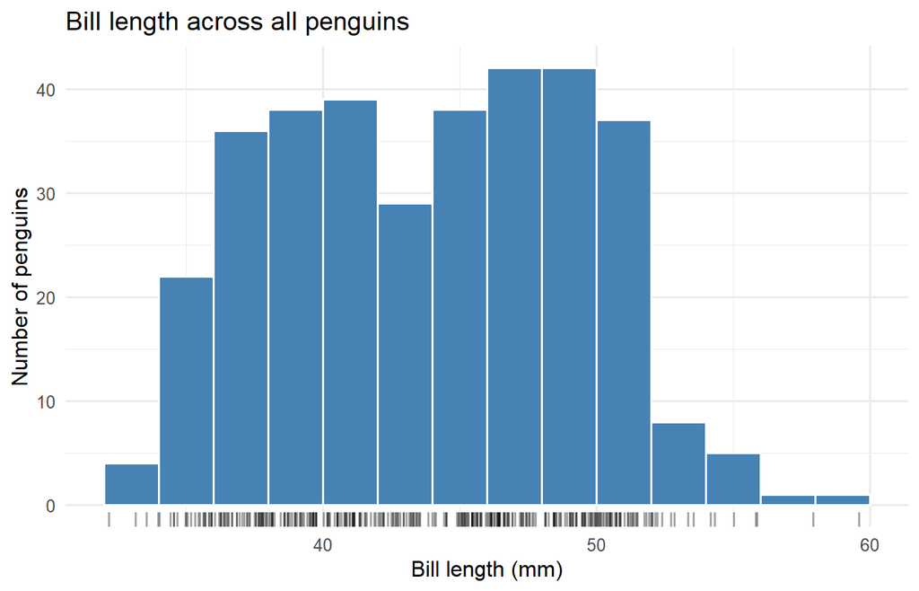

Data source: Gorman et al. (2014).

```r
ggplot(penguins_bill, aes(x = bill_len)) +
  geom_histogram(
    binwidth = 2,
    boundary = 30,
    color = "white",
    fill = "steelblue"
  ) +
  geom_rug(
    aes(y = 0),
    sides = "b",
    alpha = 0.35,
    position = position_jitter(width = 0.08, height = 0)
  ) +
  labs(
    title = "Bill length across all penguins",
    x = "Bill length (mm)",
    y = "Number of penguins"
  )
```

The ungrouped histogram shows a broad distribution with more than one visible concentration of values. A bin width of 2 mm is a reasonable baseline because it is narrow enough to show the uneven shape but not so narrow that every small fluctuation looks important.

#### b. Bin Width

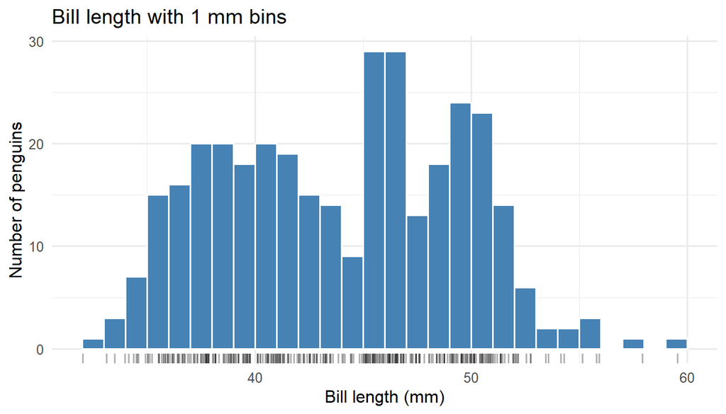

Data source: Gorman et al. (2014).

```r
ggplot(penguins_bill, aes(x = bill_len)) +
  geom_histogram(
    binwidth = 1,
    boundary = 30,
    color = "white",
    fill = "steelblue"
  ) +
  geom_rug(
    aes(y = 0),
    sides = "b",
    alpha = 0.30,
    position = position_jitter(width = 0.08, height = 0)
  ) +
  labs(
    title = "Bill length with 1 mm bins",
    x = "Bill length (mm)",
    y = "Number of penguins"
  )
```

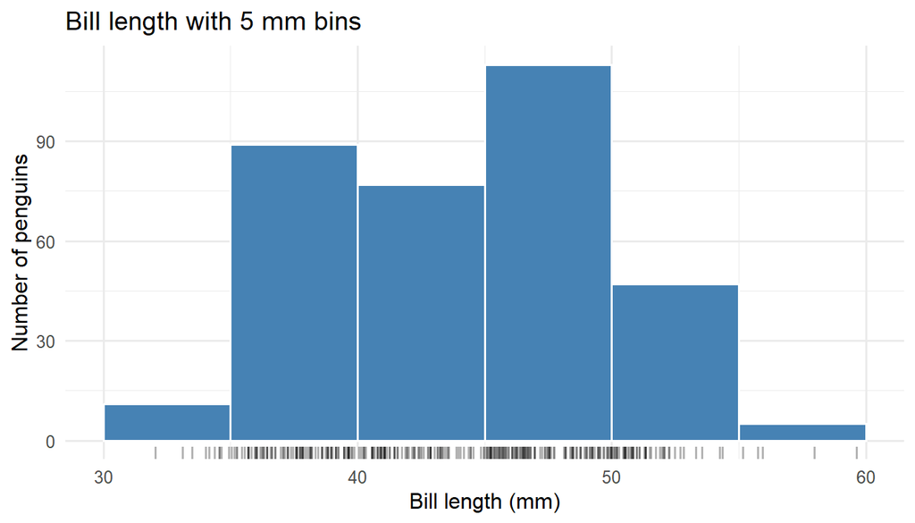

Data source: Gorman et al. (2014).

```r
ggplot(penguins_bill, aes(x = bill_len)) +
  geom_histogram(
    binwidth = 5,
    boundary = 30,
    color = "white",
    fill = "steelblue"
  ) +
  geom_rug(
    aes(y = 0),
    sides = "b",
    alpha = 0.30,
    position = position_jitter(width = 0.08, height = 0)
  ) +
  labs(
    title = "Bill length with 5 mm bins",
    x = "Bill length (mm)",
    y = "Number of penguins"
  )
```

The 1 mm bins show local detail, but they also make the shape look noisier. The 5 mm bins make the plot cleaner but hide some of the separation between the shorter and longer bill groups. The 2 mm version is the best choice for the report because it keeps the main structure visible without over-emphasising small bin-to-bin changes.

#### c. Histogram Interpretation

The bill-length distribution is not unimodal because the plot pools three species with different typical bill lengths. Shorter bills mostly come from Adelie penguins, while Chinstrap and Gentoo penguins tend to have longer bills. Pooling the species therefore creates a shape that is partly about species membership, not just one continuous population.

#### d. Raw Point Plot by Species

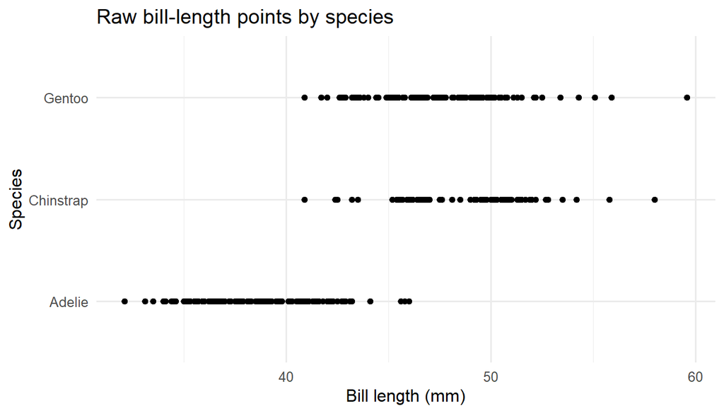

Data source: Gorman et al. (2014).

```r
ggplot(penguins_bill, aes(x = bill_len, y = species)) +
  geom_point() +
  labs(
    title = "Raw bill-length points by species",
    x = "Bill length (mm)",
    y = "Species"
  )
```

The raw point plot shows the species groups, but many points sit directly on top of each other because the y-axis has only three possible values. This makes the apparent density unreliable: dark areas mean overlap, but the exact number of penguins at each bill length is hard to judge.

#### e. Jitter Plot

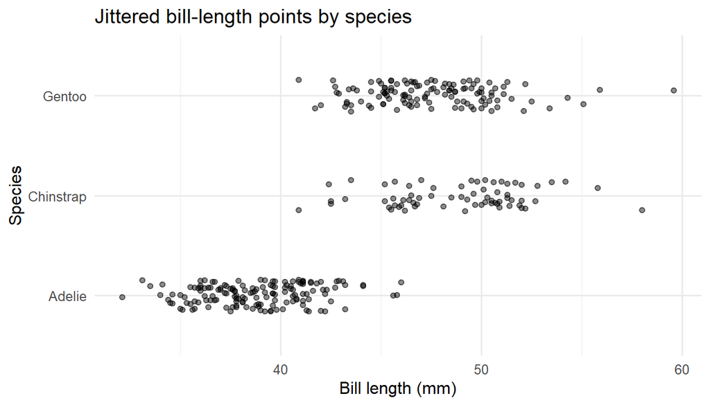

Data source: Gorman et al. (2014).

```r
ggplot(penguins_bill, aes(x = bill_len, y = species)) +
  geom_jitter(width = 0, height = 0.16, alpha = 0.45) +
  labs(
    title = "Jittered bill-length points by species",
    x = "Bill length (mm)",
    y = "Species"
  )
```

The jitter plot makes the relative densities much easier to see than the raw point plot. It shows that Adelie bill lengths are mostly shorter, while Chinstrap and Gentoo have many values in the high 40s and low 50s. The vertical jitter is useful here because it separates overlapping points without changing the measured bill lengths on the x-axis.

#### f. Beeswarm Plot

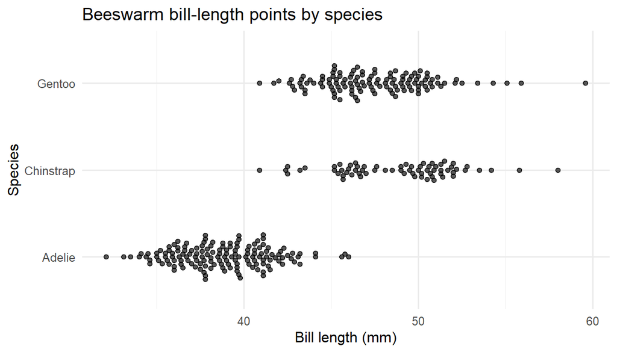

Data source: Gorman et al. (2014).

```r
ggplot(penguins_bill, aes(x = bill_len, y = species)) +
  geom_beeswarm(alpha = 0.65, cex = 1.4, priority = "ascending") +
  labs(
    title = "Beeswarm bill-length points by species",
    x = "Bill length (mm)",
    y = "Species"
  )
```

The beeswarm plot uses an algorithmic offset rather than random jitter: it moves points just enough perpendicular to the measurement axis to reduce overlap while preserving bill length on the x-axis. Because the packing is computed from point size, figure size, device resolution, and the order in which observations are placed, the exact stack shape can differ when the graph is redrawn with another output size or different plotting settings. That difference does not mean the data changed; the correct interpretation is the horizontal bill-length position and the wider or narrower clusters within each species, not the exact vertical position of any dot.

#### g. Pros and Cons - Jitter versus Beeswarm

The jitter plot is useful because it is simple and easy to explain. Since we set the horizontal jitter to zero, the bill-length values on the x-axis stay correct, while the vertical jitter spreads out points that would otherwise sit directly on top of one another. This makes it easier to notice that Adelie penguins are concentrated at shorter bill lengths, while Chinstrap and Gentoo penguins are concentrated at longer bill lengths.

The main disadvantage of jitter is that the vertical movement is artificial. The exact y-position of a point is not a real measurement; it is only a display adjustment. If the jitter height is too small, many points still overlap, but if it is too large, points from neighbouring species rows can start to look mixed together. The `set.seed()` call makes the jitter reproducible in this report, but the positions would change if the seed or jitter settings changed.

The beeswarm plot has the advantage of using a more systematic offset. Instead of scattering points randomly, it packs nearby observations so that dense bill-length ranges become visible as wider clusters of dots. For these penguin data, this helps us compare the density within each species row while still keeping each point close to its true bill-length value. The exact packing may vary across output sizes because the algorithm recalculates how much room each dot needs, but the bill-length values and species groups remain unchanged.

The disadvantage of the beeswarm plot is that it is less familiar and can look visually busier. The sideways packing should not be interpreted as another variable, but a reader who has not seen beeswarm plots before may need a moment to understand it. It also depends on the `ggbeeswarm` package, whereas jitter is available directly in `ggplot2`. For this dataset, we would use the beeswarm plot when we want to emphasise individual observations and local density, but the jitter plot is still a good simpler option for a general audience.

#### h. Faceted Bill-Length Histogram

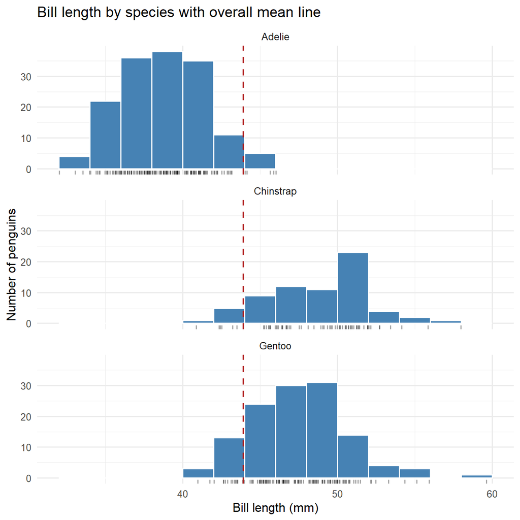

Data source: Gorman et al. (2014).

```r
overall_bill_len_mean <- mean(penguins_bill$bill_len)

ggplot(penguins_bill, aes(x = bill_len)) +
  geom_histogram(
    binwidth = 2,
    boundary = 30,
    color = "white",
    fill = "steelblue"
  ) +
  geom_rug(
    aes(y = 0),
    sides = "b",
    alpha = 0.35,
    position = position_jitter(width = 0.08, height = 0)
  ) +
  geom_vline(
    xintercept = overall_bill_len_mean,
    linewidth = 0.8,
    linetype = "dashed",
    color = "firebrick"
  ) +
  facet_wrap(~species, ncol = 1) +
  labs(
    title = "Bill length by species with overall mean line",
    x = "Bill length (mm)",
    y = "Number of penguins"
  )
```

The faceted view shows why the pooled histogram is not unimodal. Adelie penguins are mostly to the left of the overall mean line, Chinstrap penguins are mostly to the right, and Gentoo penguins are also mostly longer-billed but overlap with Chinstrap.

#### i. Violin-with-Box Plot

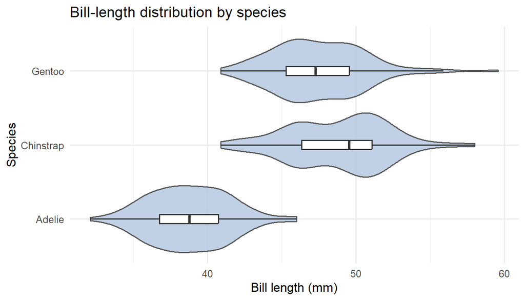

Data source: Gorman et al. (2014).

```r
ggplot(penguins_bill, aes(x = bill_len, y = species)) +
  geom_violin(fill = "lightsteelblue", color = "grey35", alpha = 0.8) +
  geom_boxplot(width = 0.12, outlier.shape = NA, fill = "white") +
  labs(
    title = "Bill-length distribution by species",
    x = "Bill length (mm)",
    y = "Species"
  )
```

#### j. Why Combine Violin and Box Plots

The violin plot shows the full shape of each species distribution, including where the values are dense or thin. The box plot adds a compact summary of the median and interquartile range. Combining them is more informative than either one alone because the reader can see both distribution shape and summary statistics in the same view.

### 3.3 Distribution of Bill Depth

#### a. Ungrouped Bill-Depth Histogram

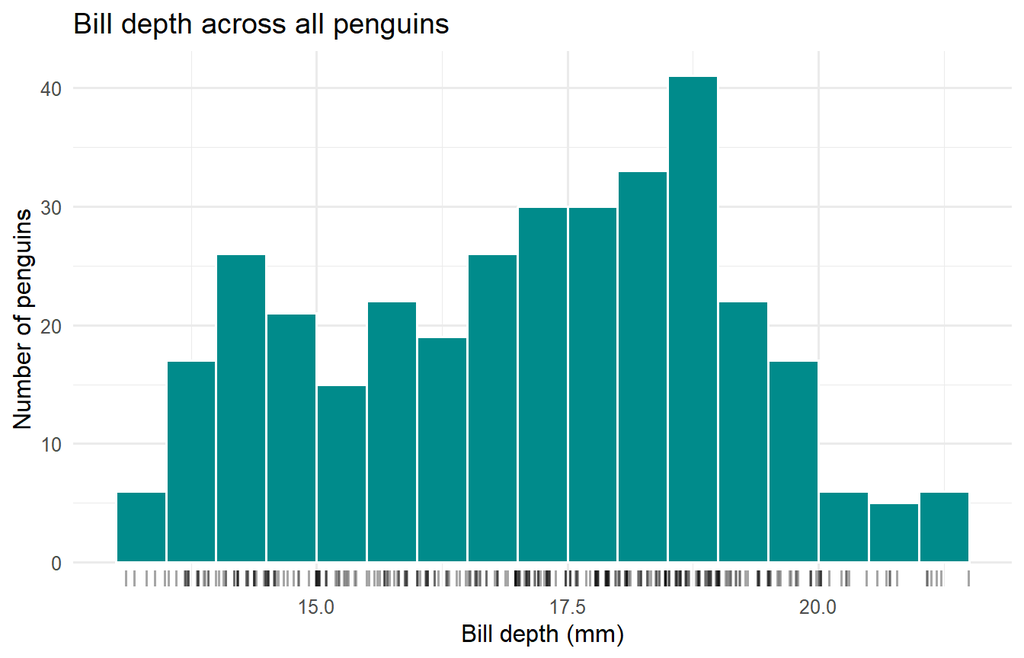

Data source: Gorman et al. (2014).

```r
ggplot(penguins_bill, aes(x = bill_dep)) +
  geom_histogram(
    binwidth = 0.5,
    boundary = 13,
    color = "white",
    fill = "darkcyan"
  ) +
  geom_rug(
    aes(y = 0),
    sides = "b",
    alpha = 0.35,
    position = position_jitter(width = 0.03, height = 0)
  ) +
  labs(
    title = "Bill depth across all penguins",
    x = "Bill depth (mm)",
    y = "Number of penguins"
  )
```

The pooled bill-depth distribution is also broad, but it separates the species in a different way from bill length. Bill length mostly separates Adelie from the longer-billed species, while bill depth gives a clearer low-depth group that is mainly Gentoo.

#### b. Faceted Bill-Depth Histogram

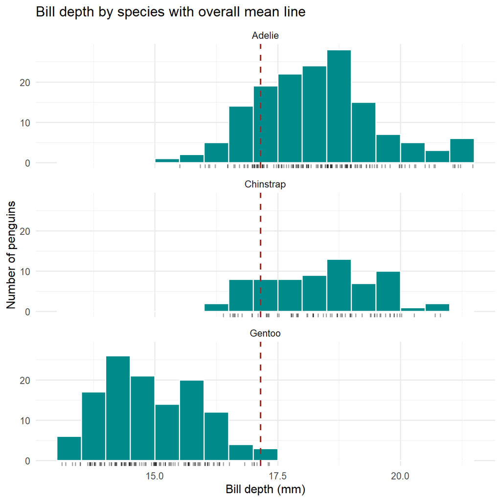

Data source: Gorman et al. (2014).

```r
overall_bill_dep_mean <- mean(penguins_bill$bill_dep)

ggplot(penguins_bill, aes(x = bill_dep)) +
  geom_histogram(
    binwidth = 0.5,
    boundary = 13,
    color = "white",
    fill = "darkcyan"
  ) +
  geom_rug(
    aes(y = 0),
    sides = "b",
    alpha = 0.35,
    position = position_jitter(width = 0.03, height = 0)
  ) +
  geom_vline(
    xintercept = overall_bill_dep_mean,
    linewidth = 0.8,
    linetype = "dashed",
    color = "firebrick"
  ) +
  facet_wrap(~species, ncol = 1) +
  labs(
    title = "Bill depth by species with overall mean line",
    x = "Bill depth (mm)",
    y = "Number of penguins"
  )
```

The faceted bill-depth plot shows that Gentoo penguins have noticeably shallower bills than the other two species. Adelie and Chinstrap bill depths overlap much more, so bill depth alone does not separate those two species well.

#### c. Comparison of Bill-Length and Bill-Depth Distributions

```r
species_bill_summary <- penguins_bill |>
  summarize(
    mean_bill_len = round(mean(bill_len), 2),
    mean_bill_dep = round(mean(bill_dep), 2),
    n = n(),
    .by = species
  ) |>
  arrange(species)

species_bill_summary
```

```
# A tibble: 3 × 4
  species   mean_bill_len mean_bill_dep     n
  <fct>             <dbl>         <dbl> <int>
1 Adelie             38.8          18.4   151
2 Chinstrap          48.8          18.4    68
3 Gentoo             47.5          15.0   123
```

**Verifier cross-check.** The species summary supports the visual claims: Adelie has the shortest mean bill length, while Gentoo has the lowest mean bill depth. Bill length helps separate Adelie from the other species, and bill depth helps separate Gentoo from the other species. The two measurements therefore separate different species pairs rather than giving the same information twice.

### 3.4 Bivariate View: Bill Depth versus Bill Length

#### a. Ungrouped Scatter Plot

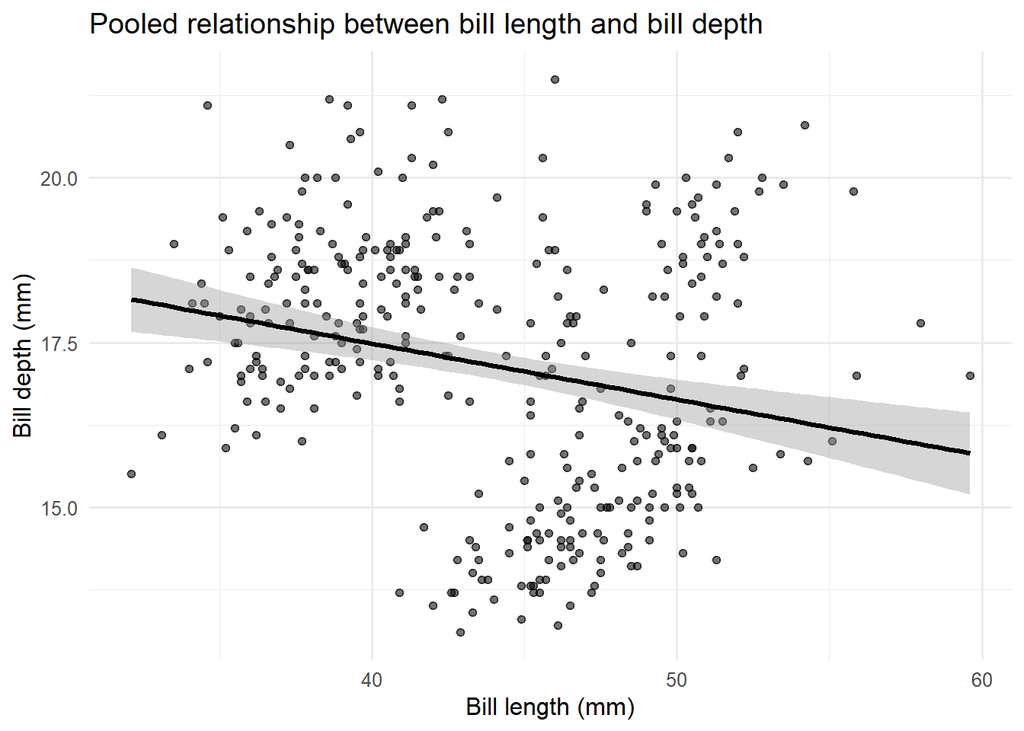

Data source: Gorman et al. (2014).

```r
ggplot(penguins_bill, aes(x = bill_len, y = bill_dep)) +
  geom_point(alpha = 0.55) +
  geom_smooth(method = "lm", color = "black") +
  labs(
    title = "Pooled relationship between bill length and bill depth",
    x = "Bill length (mm)",
    y = "Bill depth (mm)"
  )
```

#### b. Interpretation of the Pooled Trend

The pooled trend line slopes downward, so a reader without species information might think longer bills are generally associated with shallower bills. The confidence band is fairly narrow around the fitted line, so the pooled plot suggests a non-zero negative relationship. This is misleading because the pooled result mixes three species groups that have different centres in the scatter plot.

#### c. Exact Overplotting

```r
overlap_count_check <- penguins_bill |>
  count(bill_len, bill_dep, name = "stack_n")

overlap_summary <- overlap_count_check |>
  summarize(
    hidden_points = sum(stack_n - 1),
    max_stack = max(stack_n)
  )

overlap_summary
```

```
# A tibble: 1 × 2
  hidden_points max_stack
          <dbl>     <int>
1             4         2
```

Using `count()`, the number of points hidden by exact overlap is 4, and the largest exact stack at one coordinate contains 2 penguins.

**Verifier cross-check.** The same hidden-point count can be checked with `distinct()`.

```r
hidden_points_distinct <- nrow(penguins_bill) -
  nrow(distinct(penguins_bill, bill_len, bill_dep))

tibble(
  hidden_points_from_count = overlap_summary$hidden_points,
  hidden_points_from_distinct = hidden_points_distinct,
  matches = hidden_points_from_count == hidden_points_from_distinct
)
```

```
# A tibble: 1 × 3
  hidden_points_from_count hidden_points_from_distinct matches
                     <dbl>                       <int> <lgl>
1                        4                           4 TRUE
```

Exact duplicate coordinates are not the only cause of overplotting. Points can also hide each other when symbols overlap visually even if their recorded measurements are slightly different.

#### d. Mitigation of Overplotting

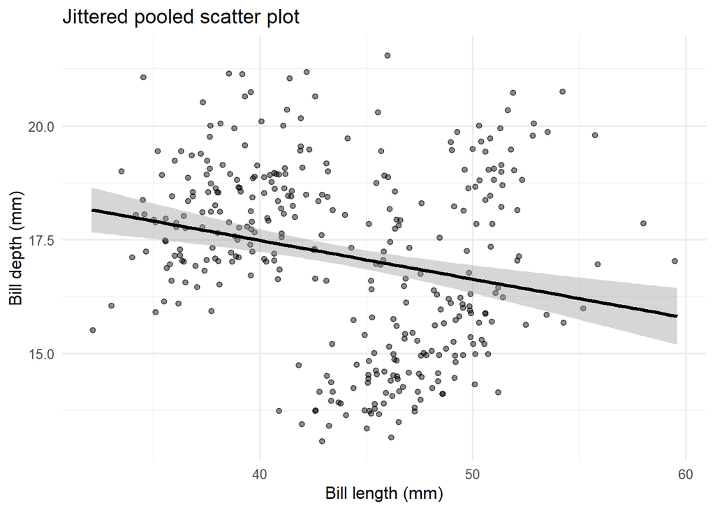

Data source: Gorman et al. (2014).

```r
ggplot(penguins_bill, aes(x = bill_len, y = bill_dep)) +
  geom_jitter(width = 0.12, height = 0.06, alpha = 0.45) +
  geom_smooth(method = "lm", color = "black") +
  labs(
    title = "Jittered pooled scatter plot",
    x = "Bill length (mm)",
    y = "Bill depth (mm)"
  )
```

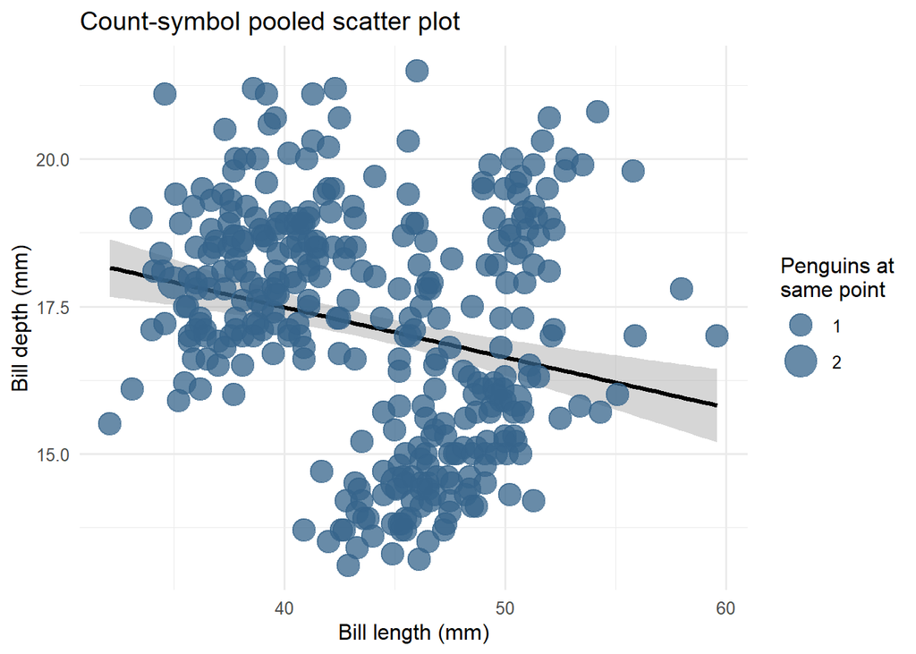

Data source: Gorman et al. (2014).

```r
ggplot(penguins_bill, aes(x = bill_len, y = bill_dep)) +
  geom_smooth(method = "lm", color = "black") +
  geom_count(alpha = 0.75, color = "steelblue4") +
  scale_size_area(
    max_size = 8,
    breaks = c(1, 2),
    name = "Penguins at\nsame point"
  ) +
  labs(
    title = "Count-symbol pooled scatter plot",
    x = "Bill length (mm)",
    y = "Bill depth (mm)"
  )
```

#### e. Assessment of Scatter Plot Variants

The count-symbol scatter plot from part d.ii is the strongest choice for a journal-style figure. It preserves the measured coordinates and shows exact duplicate coordinates with symbol size, while the jittered plot moves the observations slightly. The count-symbol plot does not solve every visual-overlap problem, but it is more faithful to the recorded measurement values than jitter for this dataset.

#### f. Grouped Scatter Plot

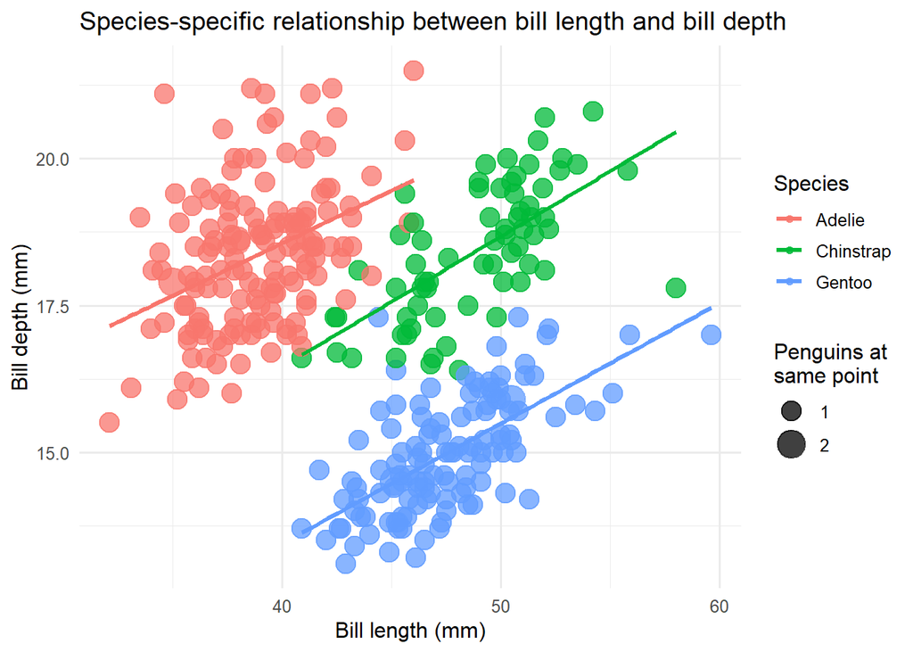

Data source: Gorman et al. (2014).

```r
ggplot(penguins_bill, aes(x = bill_len, y = bill_dep, color = species)) +
  geom_count(alpha = 0.75) +
  geom_smooth(method = "lm", se = FALSE) +
  scale_size_area(
    max_size = 7,
    breaks = c(1, 2),
    name = "Penguins at\nsame point"
  ) +
  labs(
    title = "Species-specific relationship between bill length and bill depth",
    x = "Bill length (mm)",
    y = "Bill depth (mm)",
    color = "Species"
  )
```

Mapping species to colour makes the hidden grouping visible. The pooled scatter plots all show the same general negative trend: when species is ignored, points with longer bills tend to sit lower on the bill-depth axis, so the overall fitted line slopes downward. The grouped scatter plot shows the opposite pattern inside the species groups: within Adelie, Chinstrap, and Gentoo, the fitted lines slope upward, meaning longer bills within the same species tend to go with deeper bills. These trends oppose each other because the pooled plot mixes two different effects: differences between species averages and relationships within each species. Gentoo penguins are generally longer-billed but shallower-billed than Adelie penguins, so combining the species pulls the overall line downward even though the within-species lines slope upward. The statistical term for this apparent reversal between the pooled and grouped trends is Simpson’s paradox.

**Verifier cross-check.** The correlation signs should match the slopes seen in the scatter plots.

```r
pooled_correlation <- tibble(
  group = "All species pooled",
  correlation = round(cor(penguins_bill$bill_len, penguins_bill$bill_dep), 3)
)

species_correlations <- penguins_bill |>
  summarize(
    correlation = round(cor(bill_len, bill_dep), 3),
    .by = species
  ) |>
  rename(group = species)

bind_rows(pooled_correlation, species_correlations)
```

```
# A tibble: 4 × 2
  group              correlation
  <chr>                    <dbl>
1 All species pooled      -0.235
2 Adelie                   0.391
3 Gentoo                   0.643
4 Chinstrap                0.654
```

The verifier output matches the visual pattern: the pooled correlation is negative, while each species has a positive correlation between bill length and bill depth.

### 3.5 Summarize the Insights Gained

Bill length and bill depth can help distinguish the three Pygoscelis species, but each measurement separates the species in a different way. The bill-length plots show Adelie penguins tending to have shorter bills, while Chinstrap and Gentoo penguins overlap more in length. The bill-depth plots show Gentoo penguins tending to have shallower bills, while Adelie and Chinstrap overlap more in depth. Simpson’s paradox appears in the scatter plots because the trend for the combined data points in the opposite direction from the trends inside the species groups. In the pooled scatter plot, longer bills appear to be associated with shallower bills, giving a negative overall relationship. After species is added, each species-specific regression line slopes upward, meaning that within Adelie, Chinstrap, and Gentoo groups, penguins with longer bills also tend to have deeper bills. The pooled negative trend is therefore misleading because it mixes species with different average bill shapes, and these observations are consistent with Horst, Hill, and Gorman (2022), who use the Palmer penguins data to show how species grouping changes the interpretation of bill measurements.

**Verifier cross-check.** The summary above is consistent with the numeric checks: the species means support the histogram interpretations, and the correlation table supports the Simpson’s paradox interpretation.

### 3.6 Consolidate the Results

The verifier checks are included directly after the relevant tasks, using row-count checks, range checks, species summaries, duplicate-coordinate checks, and correlation checks. All required plots in this report are produced with `ggplot`, include axis labels with units, and include the caption “Data source: Gorman et al. (2014).” The only package outside the core tidyverse and `ggbeeswarm` is `palmerpenguins`, which is loaded only because it provides the `penguins` dataset in this environment.

## 4 Completing Your Submission

### 4.1 Reflect on AI Use

The team used Codex as the chat-based AI tool for this report. A useful AI suggestion was to compute scalar values, such as the overall mean bill length and bill depth, as named objects before passing them to `geom_vline()`. This made the code easier to check and allowed the same values to be reused in the written explanation. One AI response was misleading because it initially placed `mean(bill_len)` inside `aes(xintercept = ...)` in a faceted plot, which rendered without an error but produced a different mean line in each species panel. The team caught this by comparing the plotted lines with an independent summary table, then corrected the code by computing the overall mean outside `ggplot()` and passing it as a fixed `xintercept`. The team reviewed the generated code against the rendered output and kept only the parts that matched the assignment rules.

### 4.2 List Each Member’s Role and Contributions

| Role | Member | Contributions |
| --- | --- | --- |
| Coder | Joshua | Created the canonical QMD, wrote the R chunks, checked chunk labels, and rendered the HTML draft. |
| Navigator + Verifier | Benjamin | Checked the task list, reviewed row counts, species summaries, duplicate-point checks, and correlation checks. |
| Constructive Critic + Reporter | Dannon | Reviewed explanations for clarity, checked that the plot choices were justified, and prepared team-facing summary text. |
| AI Liaison | MeiYuen | Managed the AI interaction log, identified useful and incomplete AI output, and checked that AI use followed the lab rules. |

## References

Gorman, K.B., Williams, T.D. and Fraser, W.R. (2014). Ecological sexual dimorphism and environmental variability within a community of Antarctic penguins (genus Pygoscelis). *PLOS ONE*, 9(3), 1-14. https://doi.org/10.1371/journal.pone.0090081.

Horst, A.M., Hill, A.P. and Gorman, K.B. (2020). Palmerpenguins: Palmer Archipelago (Antarctica) penguin data. https://doi.org/10.5281/zenodo.3960218.

Horst, A.M., Hill, A.P. and Gorman, K.B. (2022). Palmer Archipelago Penguins Data in the palmerpenguins R Package - An Alternative to Anderson’s Irises. *The R Journal*, 14(1), 244-254. https://doi.org/10.32614/RJ-2022-020.